# Simulated Data Visualization

Erik Westlund

2024-11-20

## Basic Visualizations

### Provider Trust

From our causal model, we theorize three causes of provider trust:

- Provider quality
- Race/ethnicity
- Cultural orientation (namely, trust in institutions)

We observe race, but we do not observe provider quality or cultural orientation.

## Provider quality

For provider quality, we hypothesize the political and economic conditions with respect to healthcare will influence provider quality. We do not observe provider quality directly, but we do observe what state the provider is in.

Given all this, it may help us to see:

- A breakdown of race/ethnicity
- A breakdown of receipt of comprehensive care by race/ethnicity
- A breakdown of receipt of comprehensive care by state
- A breakdown of receipt of comprehensive care by race by state

### Race/ethnicity

For categorical variables, we typically first want to see a bar chart of the distribution of the variable.

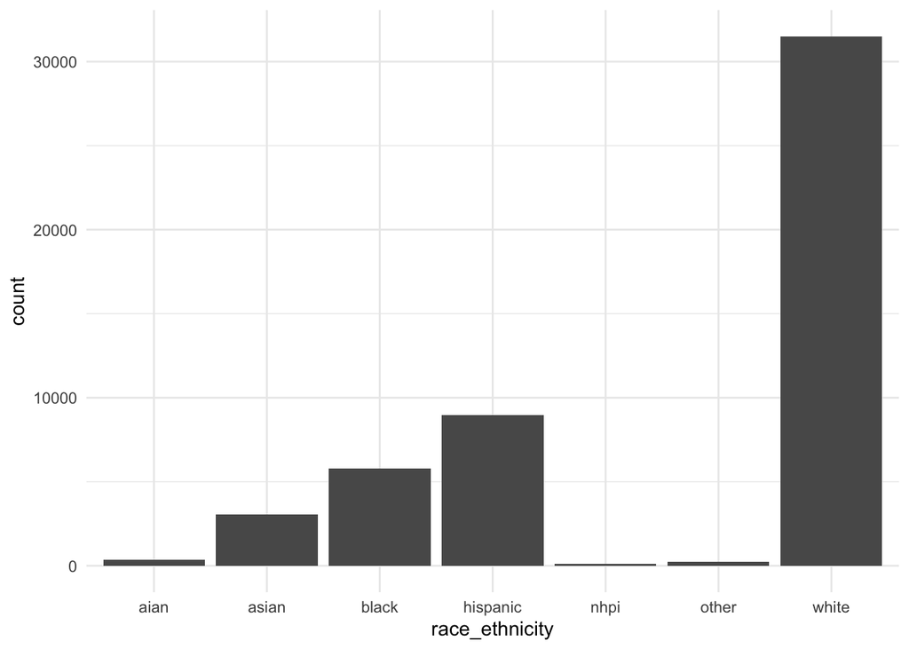

```r
# Bar chart
ggplot(data, aes(race_ethnicity)) +
  geom_bar() +
  theme_minimal()
```

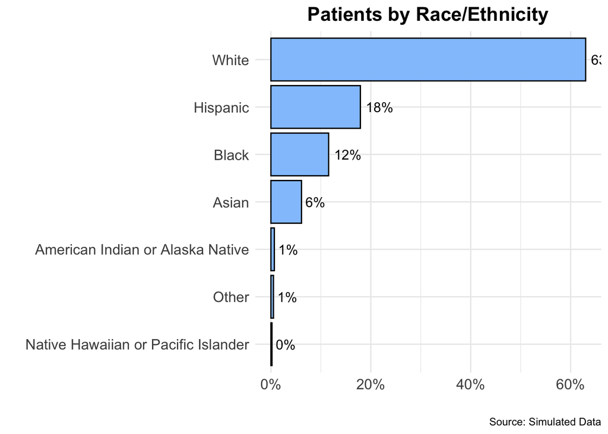

```r
ggsave("images/report/race_ethnicity_1.png", width = 6, height = 4, dpi=300)


# Do using a summarize
  ggplot(
    data |>
      count(race_ethnicity) |>
      mutate(
        proportion = n / sum(n),
        race_ethnicity = fct_recode(
          factor(race_ethnicity),
          !!! race_ethnicity_labels
        )
      ) |>
      arrange(desc(proportion)) |>
      mutate(race_ethnicity = fct_inorder(race_ethnicity) |> fct_rev())
    ,
    aes(x = proportion, y = race_ethnicity)
  ) +
  geom_bar(stat = "identity",
           fill = colors$blue$`300`,
           color = "black") +
  geom_text(aes(label = scales::percent(proportion, accuracy = 1)),
            hjust = -0.2,
            size = 4) +
  scale_x_continuous(labels = scales::percent_format(accuracy = 1)) +
  labs(x = "", y = "", title = "Patients by Race/Ethnicity", caption = "Source: Simulated Data") +
  theme_minimal() +
  theme(
    axis.text = element_text(size = 12),
    axis.title = element_text(size = 14, face = "bold"),
    plot.title = element_text(hjust = 0.5, size = 16, face = "bold")
  )
```

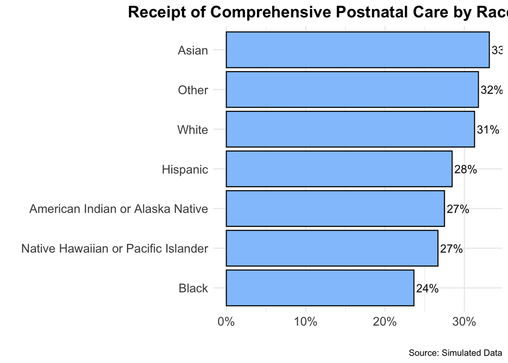

```r
ggsave("images/report/race_ethnicity_2.png",width = 12, height = 5.625, dpi = 300)

# RCP vs. Race/Ethnicity
plot_data <- data |>
  group_by(race_ethnicity) |>
  summarize(
    proportion = mean(received_comprehensive_postnatal_care),
    n = n()
  ) |>
  ungroup() |>
  mutate(
    race_ethnicity = fct_recode(factor(race_ethnicity), !!!race_ethnicity_labels),
    race_ethnicity = fct_reorder(race_ethnicity, proportion)
  )

# Plot proportions by race
ggplot(plot_data, aes(x = proportion, y = race_ethnicity)) +
  geom_bar(stat = "identity", fill = colors$blue$`300`, color = "black") +
  geom_text(
    aes(label = scales::percent(proportion, accuracy = 1)),
    hjust = -0.1,
    size = 4
  ) +
  scale_x_continuous(labels = scales::percent_format(accuracy = 1)) +
  labs(
    x = "",
    y = "",
    title = "Receipt of Comprehensive Postnatal Care by Race/Ethnicity",
    caption = "Source: Simulated Data"
  ) +
  theme_minimal() +
  theme(
    axis.text = element_text(size = 12),
    axis.title = element_text(size = 14, face = "bold"),
    plot.title = element_text(hjust = 0.5, size = 16, face = "bold")
  )
```

```r
ggsave("images/report/rcp_race_ethnicity_1.png",width = 12, height = 5.625, dpi = 300)
```

## Maps

We will now map the receipt of comprehensive postnatal care by state.

Please note that you must think hard about whether it makes sense to map the data you are mapping. For example, if you are mapping the number of people who have received comprehensive postnatal care, you must think about whether it makes sense to compare states with different populations. In our case, we know that every state is evenly represented and every person has the same probability of being in the sample. However, these assumptions rarely hold with true to life research designs.

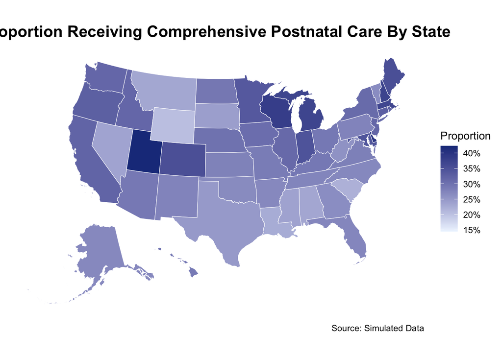

```r
us_map <- us_map(regions = "states")

rcp_by_state_data <- data |>
  group_by(state) |>
  summarize(
    proportion = mean(received_comprehensive_postnatal_care),
    n = n()
  ) |>
  ungroup()

# Merge summarized data with map data
rcp_by_state_data_mappable <- us_map |>
  left_join(
    rcp_by_state_data,
    by = c("abbr"="state")
  )

ggplot(data = rcp_by_state_data_mappable) +
  geom_sf(aes(fill = proportion), color = "white") +
  scale_fill_continuous(
    low = colors$blue$`50`,
    high = colors$blue$`900`,
    name = "Proportion",
    labels = scales::percent_format(accuracy = 1)
  ) +
  labs(
    title = "Proportion Receiving Comprehensive Postnatal Care By State",
    caption = "Source: Simulated Data"
  ) +
  theme_minimal() +
  theme(
    axis.text = element_blank(),
    axis.ticks = element_blank(),
    panel.grid = element_blank(),
    plot.title = element_text(hjust = 0.5, size = 16, face = "bold")
  )
```

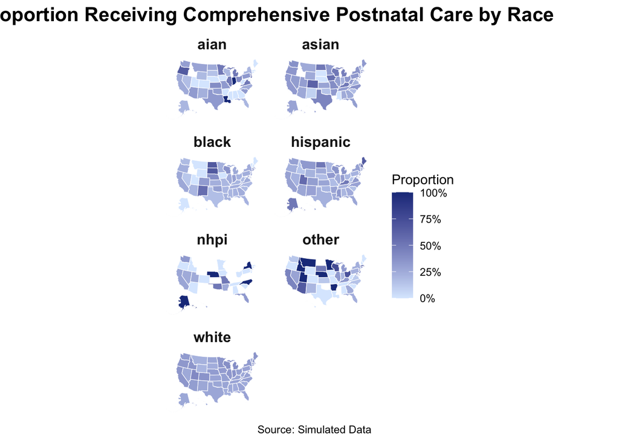

```r
ggsave("images/report/rcp_by_state.png", width = 12, height = 5.625, dpi = 300)


# Will it work? Maps  by state
race_ethnicity_care_data <- data |>
  group_by(state, race_ethnicity) |>
  summarize(
    proportion = mean(received_comprehensive_postnatal_care, na.rm = TRUE),
    .groups = "drop"
  )

race_ethnicity_care_sf <- us_map |>
  left_join(
    race_ethnicity_care_data,
    by = c("abbr" = "state")
  )

ggplot(race_ethnicity_care_sf) +
  geom_sf(aes(fill = proportion), color = "white", size = 0.2) +
  scale_fill_continuous(
    low = colors$blue$`100`,
    high = colors$blue$`900`,
    name = "Proportion",
    labels = scales::percent_format(accuracy = 1)
  ) +
  labs(
    title = "Proportion Receiving Comprehensive Postnatal Care by Race",
    caption = "Source: Simulated Data"
  ) +
  facet_wrap(~ race_ethnicity, ncol = 2) + # Facet by race, adjust columns as needed
  theme_minimal() +
  theme(
    axis.text = element_blank(),
    axis.ticks = element_blank(),
    panel.grid = element_blank(),
    plot.title = element_text(hjust = 0.5, size = 16, face = "bold"),
    strip.text = element_text(size = 12, face = "bold")
  )
```

```r
ggsave("images/report/rcp_by_race_by_state.png", width = 12, height = 5.625, dpi = 300)
```